# Praktikum 1 MPDW

Ibnu Yazid M0401241072

2026-08-26

```r
library(rio) #install packages jika belum ada
data1 <- import("https://raw.githubusercontent.com/zidyeyo/MPDW/refs/heads/main/Pertemuan%201/MPDW%20Cabai%20merah.csv")


head(data1)
```

```
##     Komoditas    Tanggal Harga
## 1 Cabai Merah 04/01/2021 57.50
## 2 Cabai Merah 05/01/2021 57.35
## 3 Cabai Merah 06/01/2021 56.35
## 4 Cabai Merah 07/01/2021 55.90
## 5 Cabai Merah 08/01/2021 54.90
## 6 Cabai Merah 11/01/2021 52.85
```

```r
data1$Harga <- as.numeric(gsub(",", ".", data1$Harga))

data_100 <- data1[1:100, ]

harga_100 <- data_100$Harga

head(data_100)
```

```
##     Komoditas    Tanggal Harga
## 1 Cabai Merah 04/01/2021 57.50
## 2 Cabai Merah 05/01/2021 57.35
## 3 Cabai Merah 06/01/2021 56.35
## 4 Cabai Merah 07/01/2021 55.90
## 5 Cabai Merah 08/01/2021 54.90
## 6 Cabai Merah 11/01/2021 52.85
```

```r
harga.ts <- ts(harga_100)


summary(harga.ts)
```

```
##    Min. 1st Qu.  Median    Mean 3rd Qu.    Max.
##   36.85   46.77   49.00   48.36   50.75   69.55
```

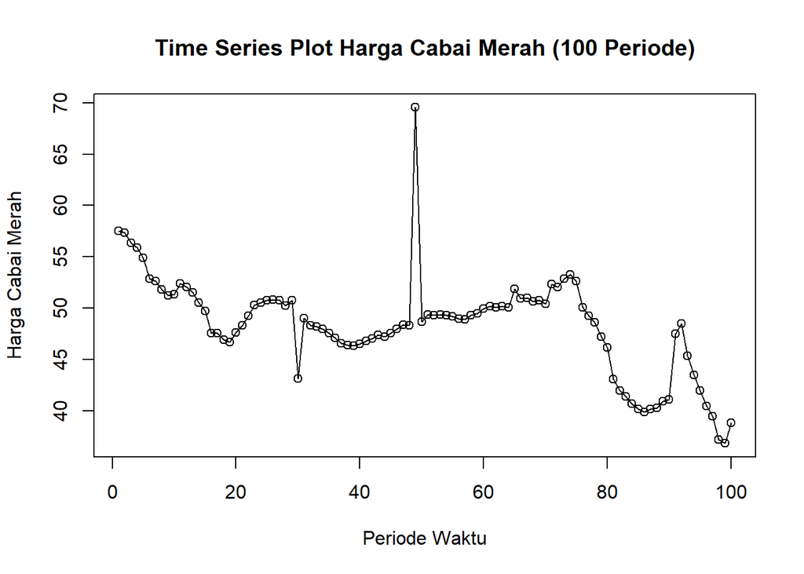

```r
ts.plot(harga.ts,
        xlab = "Periode Waktu",
        ylab = "Harga Cabai Merah",
        main = "Time Series Plot Harga Cabai Merah (100 Periode)")
points(harga.ts)
```

```r
dev.copy(png, "plot_cabai_merah.png")
```

```r
dev.off()
```

## Moving Average

```r
# 1. Hitung jumlah data (menggunakan data_100)
n <- nrow(data_100)

# 2. Tentukan batas 80% data training
n_train <- floor(0.8 * n)

# 3. Bagi data menjadi training dan testing
training_ma <- data_100[1:n_train, ]
testing_ma  <- data_100[(n_train+1):n, ]

# 4. Ubah variabel Harga ke objek time series
train_ma.ts <- ts(training_ma$Harga)
test_ma.ts  <- ts(testing_ma$Harga)
```

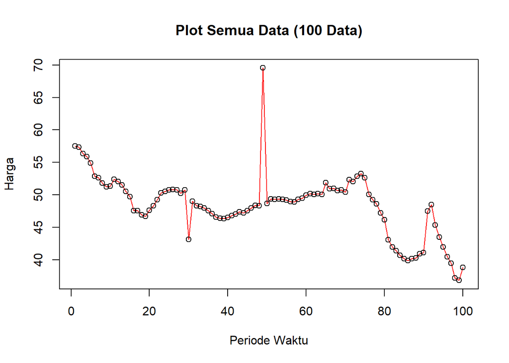

```r
# Eksplorasi keseluruhan data (100 data)
plot(harga.ts, col = "red", main = "Plot Semua Data (100 Data)", ylab = "Harga", xlab = "Periode Waktu")
points(harga.ts)
```

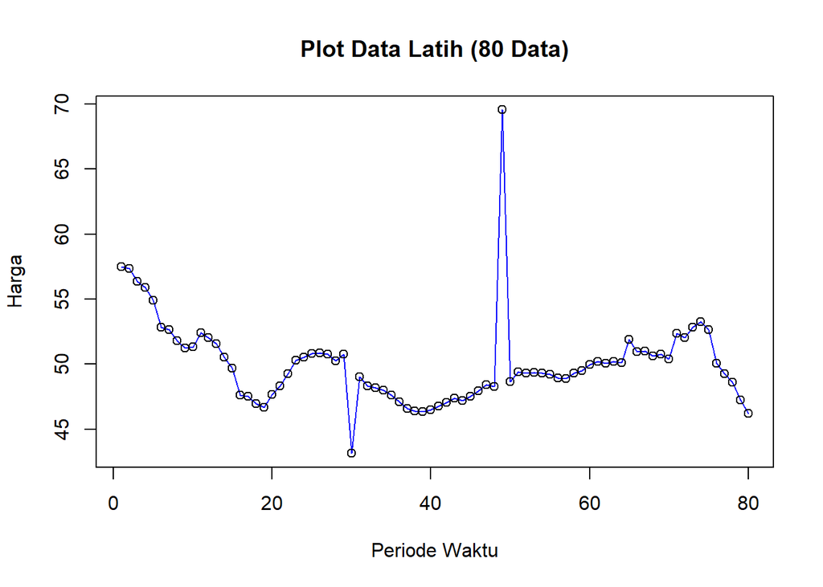

```r
# Eksplorasi data latih (80 data)
plot(train_ma.ts, col = "blue", main = "Plot Data Latih (80 Data)", ylab = "Harga", xlab = "Periode Waktu")
points(train_ma.ts)
```

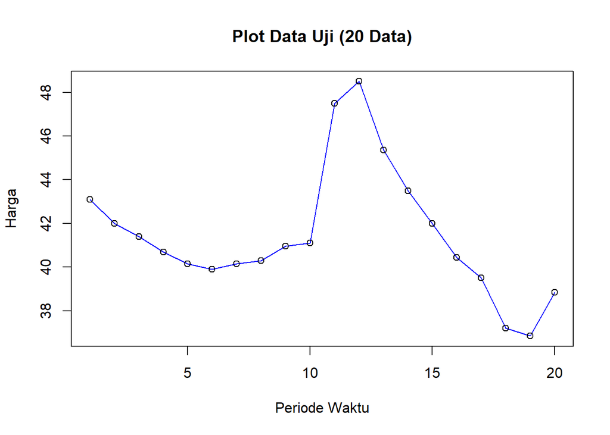

```r
# Eksplorasi data uji (20 data)
plot(test_ma.ts, col = "blue", main = "Plot Data Uji (20 Data)", ylab = "Harga", xlab = "Periode Waktu")
points(test_ma.ts)
```

```r
library(TTR)
# SMA dengan orde/period n = 3
data.sma <- SMA(train_ma.ts, n = 3)
data.sma
```

```
## Time Series:
## Start = 1
## End = 80
## Frequency = 1
##  [1]       NA       NA 57.06667 56.53333 55.71667 54.55000 53.46667 52.43333
##  [9] 51.90000 51.46667 51.66667 51.93333 52.00000 51.38333 50.60000 49.28333
## [17] 48.28333 47.36667 47.06667 47.10000 47.56667 48.41667 49.30000 50.03333
## [25] 50.55000 50.73333 50.80000 50.61667 50.58333 48.05000 47.65000 46.85000
## [33] 48.53333 48.18333 47.93333 47.56667 47.10000 46.70000 46.45000 46.41667
## [41] 46.55000 46.78333 47.08333 47.21667 47.38333 47.56667 47.96667 48.21667
## [49] 55.41667 55.50000 55.86667 49.11667 49.35000 49.31667 49.28333 49.15000
## [57] 49.01667 49.05000 49.23333 49.58333 49.88333 50.06667 50.15000 50.11667
## [65] 50.73333 50.98333 51.28333 50.86667 50.80000 50.60000 51.16667 51.60000
## [73] 52.41667 52.71667 52.91667 51.98333 50.65000 49.30000 48.36667 47.35000
```

### SMA

```r
# 1. Peramalan 1 periode ke depan
data.ramal <- c(NA, data.sma)
data.ramal # forecast 1 periode ke depan
```

```
##  [1]       NA       NA       NA 57.06667 56.53333 55.71667 54.55000 53.46667
##  [9] 52.43333 51.90000 51.46667 51.66667 51.93333 52.00000 51.38333 50.60000
## [17] 49.28333 48.28333 47.36667 47.06667 47.10000 47.56667 48.41667 49.30000
## [25] 50.03333 50.55000 50.73333 50.80000 50.61667 50.58333 48.05000 47.65000
## [33] 46.85000 48.53333 48.18333 47.93333 47.56667 47.10000 46.70000 46.45000
## [41] 46.41667 46.55000 46.78333 47.08333 47.21667 47.38333 47.56667 47.96667
## [49] 48.21667 55.41667 55.50000 55.86667 49.11667 49.35000 49.31667 49.28333
## [57] 49.15000 49.01667 49.05000 49.23333 49.58333 49.88333 50.06667 50.15000
## [65] 50.11667 50.73333 50.98333 51.28333 50.86667 50.80000 50.60000 51.16667
## [73] 51.60000 52.41667 52.71667 52.91667 51.98333 50.65000 49.30000 48.36667
## [81] 47.35000
```

```r
# 2. Peramalan untuk sisa periode data latih + data uji (total horizon peramalan)
# Menggabungkan data aktual (80 data latih), pemulusan, dan peramalan
data.gab <- cbind(
  aktual    = c(train_ma.ts),
  pemulusan = c(data.sma),
  ramalan   = c(data.ramal[1:length(train_ma.ts)])
)

data.gab
```

```
##       aktual pemulusan  ramalan
##  [1,]  57.50        NA       NA
##  [2,]  57.35        NA       NA
##  [3,]  56.35  57.06667       NA
##  [4,]  55.90  56.53333 57.06667
##  [5,]  54.90  55.71667 56.53333
##  [6,]  52.85  54.55000 55.71667
##  [7,]  52.65  53.46667 54.55000
##  [8,]  51.80  52.43333 53.46667
##  [9,]  51.25  51.90000 52.43333
## [10,]  51.35  51.46667 51.90000
## [11,]  52.40  51.66667 51.46667
## [12,]  52.05  51.93333 51.66667
## [13,]  51.55  52.00000 51.93333
## [14,]  50.55  51.38333 52.00000
```

[output cut: 66 more lines]

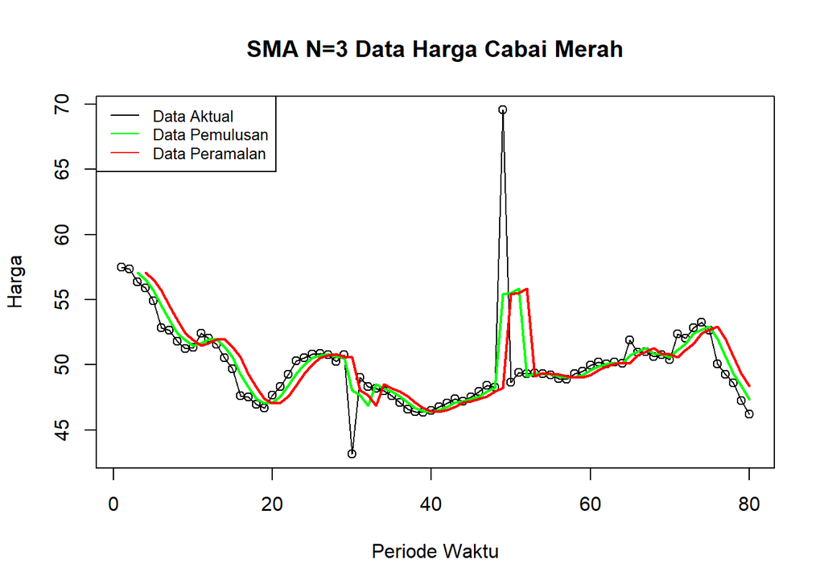

```r
# Plot data aktual (data latih)
ts.plot(train_ma.ts,
        xlab = "Periode Waktu",
        ylab = "Harga",
        main = "SMA N=3 Data Harga Cabai Merah")
points(train_ma.ts)

# Menambahkan garis data pemulusan dan peramalan dari data.gab
lines(data.gab[,2], col = "green", lwd = 2)
lines(data.gab[,3], col = "red", lwd = 2)

# Legend
legend("topleft",
       legend = c("Data Aktual", "Data Pemulusan", "Data Peramalan"),
       lty = 1,
       col = c("black", "green", "red"),
       cex = 0.8)
```

```r
#Menghitung nilai keakuratan data latih
error_train.sma = train_ma.ts-data.ramal[1:length(train_ma.ts)]

SSE_train.sma = sum(error_train.sma[5:length(train_ma.ts)]^2)
MSE_train.sma = mean(error_train.sma[5:length(train_ma.ts)]^2)
MAPE_train.sma = mean(abs((error_train.sma[5:length(train_ma.ts)]/train_ma.ts[5:length(train_ma.ts)])*100))

akurasi_train.sma <- matrix(c(SSE_train.sma, MSE_train.sma, MAPE_train.sma))
row.names(akurasi_train.sma)<- c("SSE", "MSE", "MAPE")
colnames(akurasi_train.sma) <- c("Akurasi m = 4")
akurasi_train.sma
```

```
##      Akurasi m = 4
## SSE     735.005833
## MSE       9.671129
## MAPE      2.841439
```

Dalam hal ini, nilai MAPE data latih pada metode pemulusan SMA sebesar 2.84%, nilai ini dapat dikategorikan sebagai tingkat akurasi peramalan yang sangat baik (di bawah 10%). Selanjutnya, dilakukan perhitungan nilai MAPE pada data uji untuk melihat performa metode pemulusan SMA dalam memprediksi data masa mendatang (out-of-sample).

```r
# 1. Menghitung error data uji (20 data terakhir)
# Nilai peramalan SMA untuk data uji menggunakan nilai rata-rata terakhir dari data latih
ramalan_test <- rep(data.sma[length(train_ma.ts)], length(test_ma.ts))
error_test.sma <- test_ma.ts - ramalan_test

# 2. Menghitung ukuran kebaikan model (SSE, MSE, MAPE)
SSE_test.sma  <- sum(error_test.sma^2)
MSE_test.sma  <- mean(error_test.sma^2)
MAPE_test.sma <- mean(abs(error_test.sma / test_ma.ts) * 100)

# 3. Membuat tabel matriks akurasi
akurasi_test.sma <- matrix(c(SSE_test.sma, MSE_test.sma, MAPE_test.sma))
row.names(akurasi_test.sma) <- c("SSE", "MSE", "MAPE")
colnames(akurasi_test.sma)  <- c("Akurasi m = 3")

akurasi_test.sma
```

```
##      Akurasi m = 3
## SSE      858.76250
## MSE       42.93813
## MAPE      14.97258
```

Perhitungan akurasi menggunakan data uji menghasilkan nilai MAPE sebesar 14.97% (berada di antara 10% hingga 20%), sehingga nilai akurasi ini dapat dikategorikan sebagai baik.

### DMA

```r
# 1. Menghitung Double Moving Average (DMA) dengan n = 3
dma <- SMA(data.sma, n = 3)

# 2. Menghitung komponen At dan Bt
At <- 2 * data.sma - dma
Bt <- (2 / (3 - 1)) * (data.sma - dma)

# 3. Nilai pemulusan (At + Bt) dan peramalan 1 periode
data.dma <- At + Bt
data.ramal2 <- c(NA, data.dma)

# 4. Peramalan out-of-sample untuk data uji (20 periode ke depan)
t <- 1:length(test_ma.ts) # t = 1 sampai 20
f <- c()

for (i in t) {
  f[i] <- At[length(At)] + Bt[length(Bt)] * i
}

# 5. Penggabungan data ke dalam matriks/dataframe
data.gab2 <- cbind(
  aktual     = c(train_ma.ts, rep(NA, length(test_ma.ts))),
  pemulusan1 = c(data.sma, rep(NA, length(test_ma.ts))),
  pemulusan2 = c(dma, rep(NA, length(test_ma.ts))),
  At         = c(At, rep(NA, length(test_ma.ts))),
  Bt         = c(Bt, rep(NA, length(test_ma.ts))),
  ramalan    = c(data.ramal2[1:length(train_ma.ts)], f)
)

data.gab2
```

```
##        aktual pemulusan1 pemulusan2       At           Bt  ramalan
##   [1,]  57.50         NA         NA       NA           NA       NA
##   [2,]  57.35         NA         NA       NA           NA       NA
##   [3,]  56.35   57.06667         NA       NA           NA       NA
##   [4,]  55.90   56.53333         NA       NA           NA       NA
##   [5,]  54.90   55.71667   56.43889 54.99444 -0.722222222       NA
##   [6,]  52.85   54.55000   55.60000 53.50000 -1.050000000 54.27222
##   [7,]  52.65   53.46667   54.57778 52.35556 -1.111111111 52.45000
##   [8,]  51.80   52.43333   53.48333 51.38333 -1.050000000 51.24444
##   [9,]  51.25   51.90000   52.60000 51.20000 -0.700000000 50.33333
##  [10,]  51.35   51.46667   51.93333 51.00000 -0.466666667 50.50000
##  [11,]  52.40   51.66667   51.67778 51.65556 -0.011111111 50.53333
##  [12,]  52.05   51.93333   51.68889 52.17778  0.244444444 51.64444
##  [13,]  51.55   52.00000   51.86667 52.13333  0.133333333 52.42222
##  [14,]  50.55   51.38333   51.77222 50.99444 -0.388888889 52.26667
```

[output cut: 86 more lines]

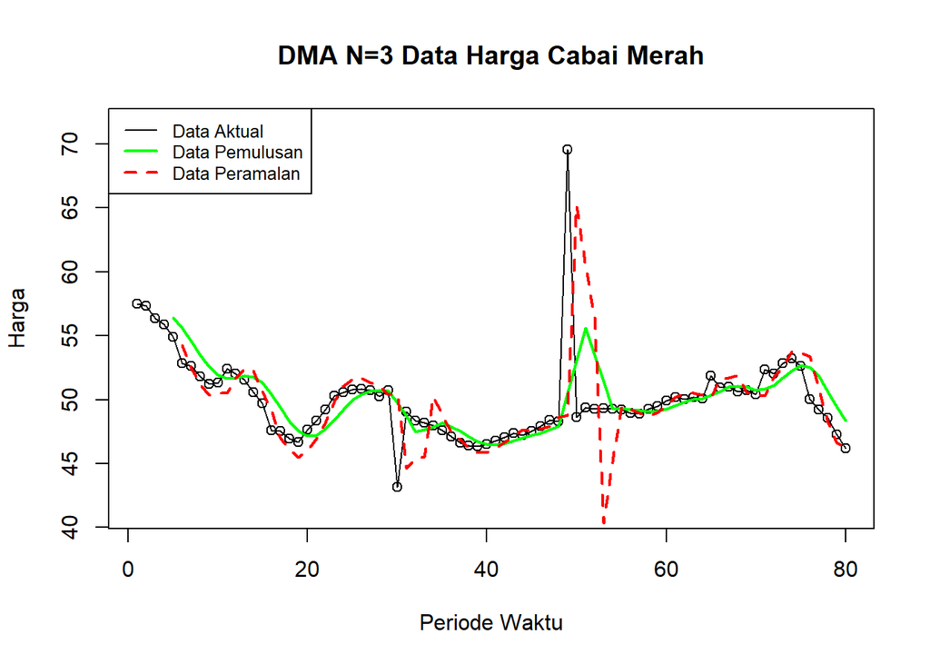

```r
# Plot data aktual (data latih)
ts.plot(train_ma.ts,
        xlab = "Periode Waktu",
        ylab = "Harga",
        main = "DMA N=3 Data Harga Cabai Merah",
        ylim = c(min(train_ma.ts, na.rm = TRUE) - 2, max(train_ma.ts, na.rm = TRUE) + 2))

points(train_ma.ts)

# Garis Pemulusan Kedua (dma) dan Garis Peramalan dari data.gab2
lines(data.gab2[, 3], col = "green", lwd = 2)             # pemulusan2 (dma)
lines(data.gab2[1:80, 6], col = "red", lwd = 2, lty = 2) # ramalan data latih

# Legend
legend("topleft",
       legend = c("Data Aktual", "Data Pemulusan", "Data Peramalan"),
       lty = c(1, 1, 2),
       col = c("black", "green", "red"),
       lwd = c(1, 2, 2),
       cex = 0.8)
```

```r
# 1. Menghitung error data latih
error_train.dma <- train_ma.ts - data.ramal2[1:length(train_ma.ts)]

# 2. Menghitung ukuran kebaikan model (mulai dari data ke-6 karena nilai NA akibat double smoothing)
SSE_train.dma  <- sum(error_train.dma[6:length(train_ma.ts)]^2)
MSE_train.dma  <- mean(error_train.dma[6:length(train_ma.ts)]^2)
MAPE_train.dma <- mean(abs(error_train.dma[6:length(train_ma.ts)] / train_ma.ts[6:length(train_ma.ts)]) * 100)

# 3. Membuat tabel matriks akurasi
akurasi_train.dma <- matrix(c(SSE_train.dma, MSE_train.dma, MAPE_train.dma))
row.names(akurasi_train.dma) <- c("SSE", "MSE", "MAPE")
colnames(akurasi_train.dma)  <- c("Akurasi m = 3")

akurasi_train.dma
```

```
##      Akurasi m = 3
## SSE    1121.709907
## MSE      14.956132
## MAPE      3.483726
```

Perhitungan akurasi pada data latih menggunakan metode Double Moving Average (DMA) menghasilkan nilai MAPE sebesar 3.48%. Karena nilai tersebut kurang dari 10%, maka tingkat akurasi model dikategorikan sebagai sangat baik. Selanjutnya, perhitungan nilai akurasi dilakukan pada data uji.

```r
# 1. Mengambil nilai hasil peramalan DMA untuk data uji (baris 81-100 pada data.gab2)
ramalan_test.dma <- data.gab2[81:100, 6]

# 2. Menghitung error data uji
error_test.dma <- test_ma.ts - ramalan_test.dma

# 3. Menghitung ukuran kebaikan model (SSE, MSE, MAPE)
SSE_test.dma  <- sum(error_test.dma^2)
MSE_test.dma  <- mean(error_test.dma^2)
MAPE_test.dma <- mean(abs(error_test.dma / test_ma.ts) * 100)

# 4. Membuat tabel matriks akurasi
akurasi_test.dma <- matrix(c(SSE_test.dma, MSE_test.dma, MAPE_test.dma))
row.names(akurasi_test.dma) <- c("SSE", "MSE", "MAPE")
colnames(akurasi_test.dma)  <- c("Akurasi m = 3")

akurasi_test.dma
```

```
##      Akurasi m = 3
## SSE     1276.68892
## MSE       63.83445
## MAPE      15.53582
```

Perhitungan akurasi menggunakan data uji pada metode Double Moving Average (DMA) menghasilkan nilai MAPE sebesar 15.54% (berada di antara 10% hingga 20%), sehingga nilai akurasi ini dapat dikategorikan sebagai baik.

## Eksponensial

```r
library(forecast)
```

```r
# 1. Pemodelan SES pada Data Latih (Optimasi Parameter Alpha Otomatis)
ses.model <- ses(train_ma.ts, h = length(test_ma.ts))

# Menampilkan ringkasan model (nilai alpha, RMSE, MAPE, dll.)
summary(ses.model)
```

```
##
## Forecast method: Simple exponential smoothing
##
## Model Information:
## Simple exponential smoothing
##
## Call:
## ses(y = train_ma.ts, h = length(test_ma.ts))
##
##   Smoothing parameters:
##     alpha = 0.3468
##
##   Initial states:
##     l = 56.3474
##
##   sigma:  3.0204
##
##      AIC     AICc      BIC
## 531.3977 531.7134 538.5437
##
## Error measures:
##                      ME     RMSE      MAE        MPE    MAPE     MASE
## Training set -0.2979681 2.982381 1.464532 -0.8103263 2.81898 1.200187
##                     ACF1
## Training set -0.02425793
##
## Forecasts:
##     Point Forecast    Lo 80    Hi 80    Lo 95    Hi 95
##  81       48.07975 44.20899 51.95052 42.15993 53.99958
##  82       48.07975 43.98278 52.17672 41.81398 54.34553
##  83       48.07975 43.76843 52.39107 41.48615 54.67335
##  84       48.07975 43.56424 52.59526 41.17387 54.98563
##  85       48.07975 43.36889 52.79061 40.87512 55.28439
##  86       48.07975 43.18133 52.97817 40.58826 55.57124
##  87       48.07975 43.00069 53.15881 40.31200 55.84751
##  88       48.07975 42.82626 53.33325 40.04523 56.11428
##  89       48.07975 42.65743 53.50207 39.78703 56.37247
##  90       48.07975 42.49371 53.66579 39.53664 56.62287
##  91       48.07975 42.33465 53.82486 39.29337 56.86613
##  92       48.07975 42.17987 53.97963 39.05667 57.10284
##  93       48.07975 42.02906 54.13045 38.82601 57.33349
##  94       48.07975 41.88191 54.27759 38.60097 57.55853
##  95       48.07975 41.73818 54.42133 38.38115 57.77835
##  96       48.07975 41.59763 54.56187 38.16620 57.99330
##  97       48.07975 41.46007 54.69944 37.95581 58.20369
##  98       48.07975 41.32530 54.83420 37.74971 58.40979
##  99       48.07975 41.19318 54.96633 37.54764 58.61186
## 100       48.07975 41.06354 55.09597 37.34938 58.81013
```

```r
# 2. Ambil Hasil Pemulusan (Data Latih) dan Peramalan (Data Uji)
ses.fitted <- ses.model$fitted   # Data pemulusan/fitted values
ses.fq     <- ses.model$mean     # Data peramalan (forecast) untuk testing

# 3. Penggabungan Data ke Matriks data.gab.ses
data.gab.ses <- cbind(
  aktual    = c(train_ma.ts, test_ma.ts),
  pemulusan = c(ses.fitted, rep(NA, length(test_ma.ts))),
  ramalan   = c(rep(NA, length(train_ma.ts)), ses.fq)
)

data.gab.ses
```

```
##        aktual pemulusan  ramalan
##   [1,]  57.50  56.34738       NA
##   [2,]  57.35  56.74715       NA
##   [3,]  56.35  56.95624       NA
##   [4,]  55.90  56.74597       NA
##   [5,]  54.90  56.45256       NA
##   [6,]  52.85  55.91408       NA
##   [7,]  52.65  54.85135       NA
##   [8,]  51.80  54.08785       NA
##   [9,]  51.25  53.29435       NA
##  [10,]  51.35  52.58530       NA
##  [11,]  52.40  52.15686       NA
##  [12,]  52.05  52.24119       NA
##  [13,]  51.55  52.17488       NA
##  [14,]  50.55  51.95815       NA
```

[output cut: 86 more lines]

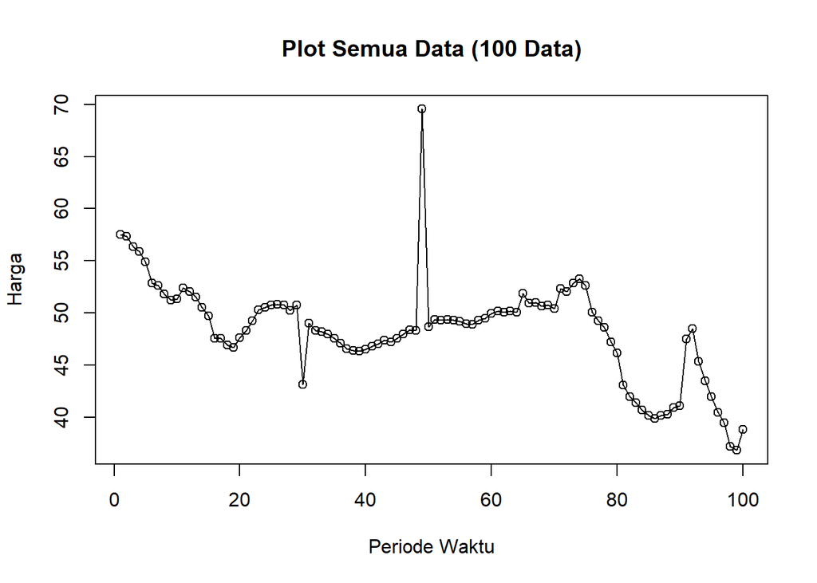

```r
# Eksplorasi keseluruhan data (100 data)
plot(harga.ts, col = "black", main = "Plot Semua Data (100 Data)", ylab = "Harga", xlab = "Periode Waktu")
points(harga.ts)
```

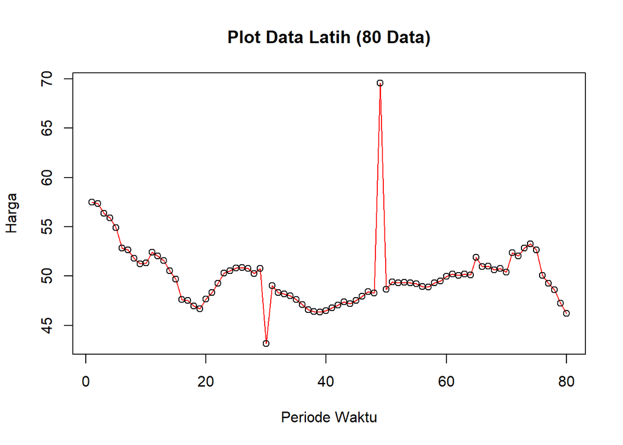

```r
# Eksplorasi data latih (80 data)
plot(train_ma.ts, col = "red", main = "Plot Data Latih (80 Data)", ylab = "Harga", xlab = "Periode Waktu")
points(train_ma.ts)
```

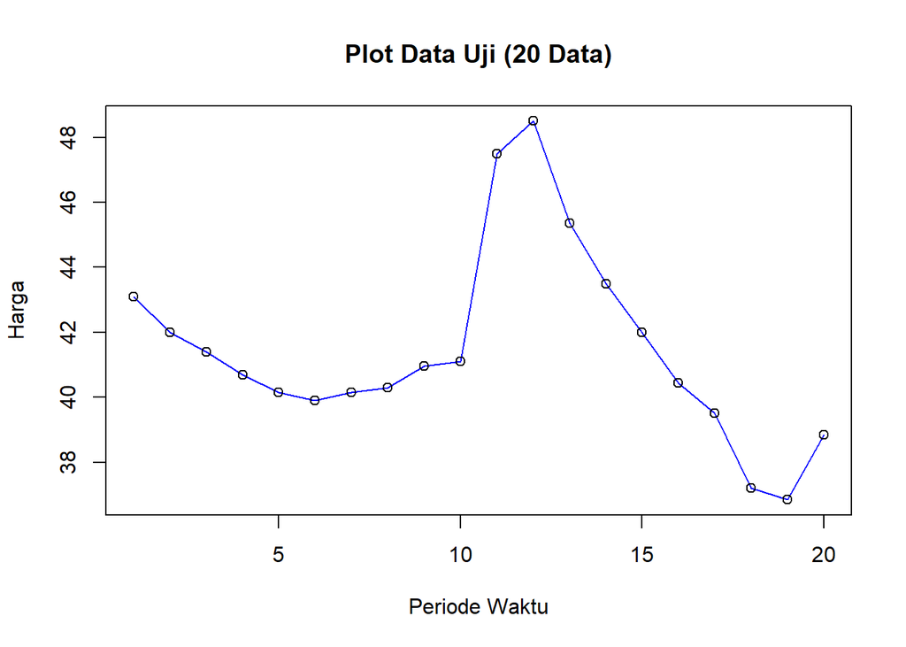

```r
# Eksplorasi data uji (20 data)
plot(test_ma.ts, col = "blue", main = "Plot Data Uji (20 Data)", ylab = "Harga", xlab = "Periode Waktu")
points(test_ma.ts)
```

### SES

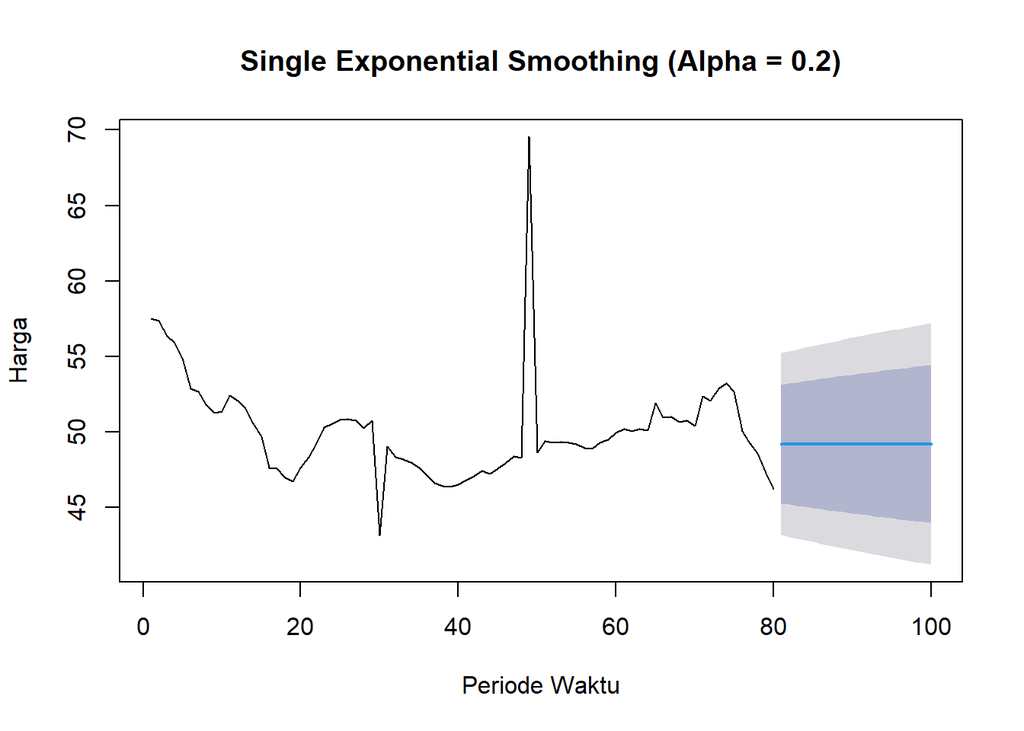

```r
# SES dengan alpha = 0.2
ses.1 <- ses(train_ma.ts, h = length(test_ma.ts), alpha = 0.2)
plot(ses.1, main = "Single Exponential Smoothing (Alpha = 0.2)", ylab = "Harga", xlab = "Periode Waktu")
```

```r
ses.1
```

```
##     Point Forecast    Lo 80    Hi 80    Lo 95    Hi 95
##  81       49.20449 45.26357 53.14541 43.17737 55.23160
##  82       49.20449 45.18552 53.22345 43.05801 55.35096
##  83       49.20449 45.10897 53.30001 42.94093 55.46805
##  84       49.20449 45.03381 53.37516 42.82599 55.58299
##  85       49.20449 44.95999 53.44899 42.71309 55.69589
##  86       49.20449 44.88743 53.52155 42.60211 55.80686
##  87       49.20449 44.81607 53.59291 42.49298 55.91600
##  88       49.20449 44.74585 53.66313 42.38559 56.02339
##  89       49.20449 44.67672 53.73226 42.27986 56.12912
##  90       49.20449 44.60863 53.80035 42.17573 56.23325
##  91       49.20449 44.54153 53.86745 42.07311 56.33587
##  92       49.20449 44.47539 53.93359 41.97195 56.43703
##  93       49.20449 44.41015 53.99882 41.87219 56.53679
##  94       49.20449 44.34580 54.06318 41.77376 56.63521
##  95       49.20449 44.28228 54.12669 41.67662 56.73235
##  96       49.20449 44.21958 54.18940 41.58072 56.82825
##  97       49.20449 44.15765 54.25133 41.48602 56.92296
##  98       49.20449 44.09647 54.31250 41.39245 57.01652
##  99       49.20449 44.03602 54.37295 41.30000 57.10898
## 100       49.20449 43.97627 54.43271 41.20862 57.20036
```

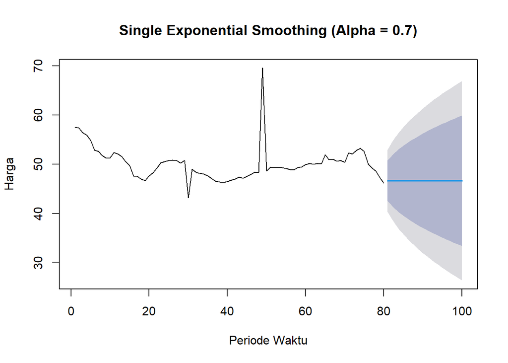

```r
# SES dengan alpha = 0.7
ses.2 <- ses(train_ma.ts, h = length(test_ma.ts), alpha = 0.7)
plot(ses.2, main = "Single Exponential Smoothing (Alpha = 0.7)", ylab = "Harga", xlab = "Periode Waktu")
```

```r
ses.2
```

```
##     Point Forecast    Lo 80    Hi 80    Lo 95    Hi 95
##  81       46.66714 42.54877 50.78551 40.36863 52.96565
##  82       46.66714 41.64003 51.69425 38.97883 54.35545
##  83       46.66714 40.87208 52.46220 37.80436 55.52993
##  84       46.66714 40.19461 53.13967 36.76826 56.56602
##  85       46.66714 39.58162 53.75266 35.83078 57.50350
##  86       46.66714 39.01760 54.31668 34.96818 58.36610
##  87       46.66714 38.49240 54.84188 34.16496 59.16932
##  88       46.66714 37.99897 55.33531 33.41032 59.92396
##  89       46.66714 37.53215 55.80213 32.69638 60.63791
##  90       46.66714 37.08805 56.24623 32.01719 61.31709
##  91       46.66714 36.66365 56.67063 31.36812 61.96616
##  92       46.66714 36.25653 57.07775 30.74549 62.58879
##  93       46.66714 35.86475 57.46953 30.14631 63.18797
##  94       46.66714 35.48669 57.84759 29.56811 63.76617
##  95       46.66714 35.12100 58.21328 29.00884 64.32544
##  96       46.66714 34.76654 58.56774 28.46674 64.86754
##  97       46.66714 34.42234 58.91194 27.94033 65.39395
##  98       46.66714 34.08755 59.24673 27.42832 65.90596
##  99       46.66714 33.76145 59.57283 26.92958 66.40470
## 100       46.66714 33.44338 59.89090 26.44314 66.89114
```

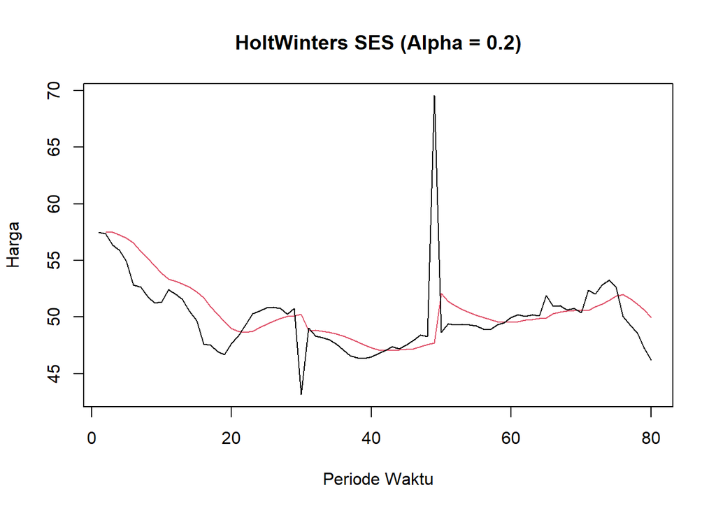

```r
# Cara 2 (Fungsi HoltWinters)

# 1. SES dengan Alpha = 0.2
ses1 <- HoltWinters(train_ma.ts, gamma = FALSE, beta = FALSE, alpha = 0.2)
plot(ses1, main = "HoltWinters SES (Alpha = 0.2)", ylab = "Harga", xlab = "Periode Waktu")
```

```r
# Ramalan 20 periode ke depan
ramalan1 <- forecast(ses1, h = length(test_ma.ts))
ramalan1
```

```
##     Point Forecast    Lo 80    Hi 80    Lo 95    Hi 95
##  81       49.20449 45.27597 53.13301 43.19633 55.21264
##  82       49.20449 45.19817 53.21081 43.07735 55.33163
##  83       49.20449 45.12185 53.28713 42.96063 55.44835
##  84       49.20449 45.04693 53.36204 42.84606 55.56292
##  85       49.20449 44.97334 53.43563 42.73351 55.67547
##  86       49.20449 44.90101 53.50797 42.62289 55.78609
##  87       49.20449 44.82987 53.57910 42.51409 55.89489
##  88       49.20449 44.75987 53.64910 42.40704 56.00194
##  89       49.20449 44.69096 53.71802 42.30165 56.10733
##  90       49.20449 44.62309 53.78589 42.19784 56.21114
##  91       49.20449 44.55620 53.85278 42.09555 56.31343
##  92       49.20449 44.49026 53.91871 41.99470 56.41427
##  93       49.20449 44.42524 53.98374 41.89525 56.51372
##  94       49.20449 44.36108 54.04789 41.79714 56.61184
##  95       49.20449 44.29777 54.11121 41.70031 56.70867
##  96       49.20449 44.23526 54.17372 41.60471 56.80427
##  97       49.20449 44.17353 54.23545 41.51030 56.89868
##  98       49.20449 44.11254 54.29643 41.41703 56.99195
##  99       49.20449 44.05228 54.35669 41.32487 57.08411
## 100       49.20449 43.99272 54.41626 41.23377 57.17521
```

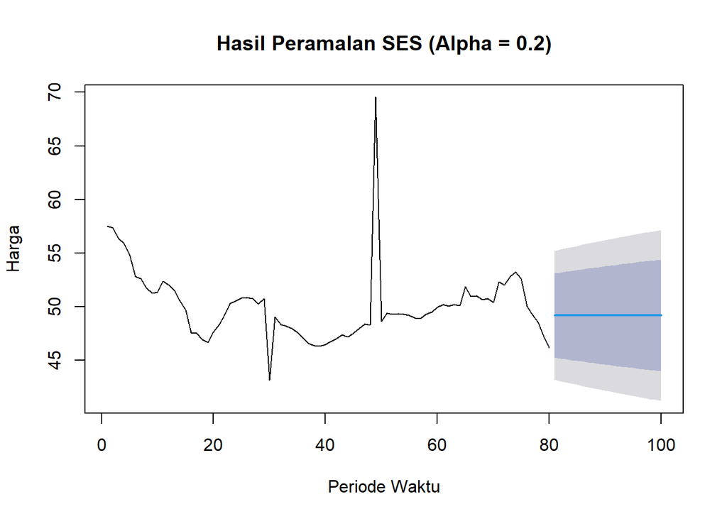

```r
plot(ramalan1, main = "Hasil Peramalan SES (Alpha = 0.2)", ylab = "Harga", xlab = "Periode Waktu")
```

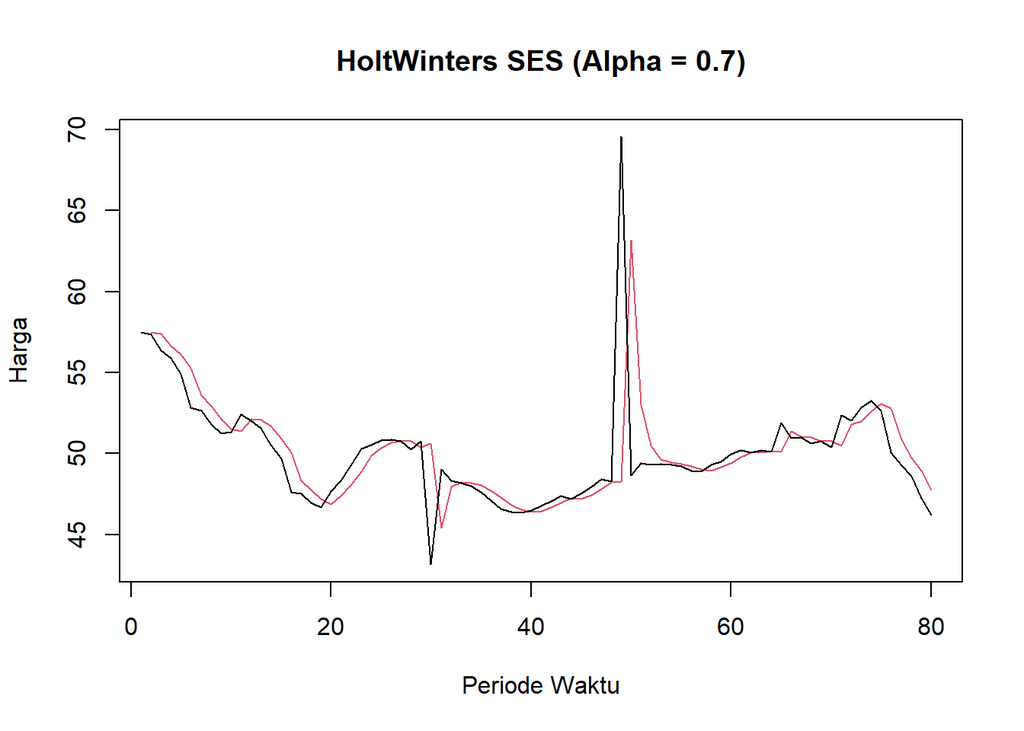

```r
# 2. SES dengan Alpha = 0.7
ses2 <- HoltWinters(train_ma.ts, gamma = FALSE, beta = FALSE, alpha = 0.7)
plot(ses2, main = "HoltWinters SES (Alpha = 0.7)", ylab = "Harga", xlab = "Periode Waktu")
```

```r
# Ramalan 20 periode ke depan
ramalan2 <- forecast(ses2, h = length(test_ma.ts))
ramalan2
```

```
##     Point Forecast    Lo 80    Hi 80    Lo 95    Hi 95
##  81       46.66714 42.55645 50.77783 40.38039 52.95390
##  82       46.66714 41.64941 51.68487 38.99318 54.34110
##  83       46.66714 40.88289 52.45139 37.82089 55.51339
##  84       46.66714 40.20669 53.12759 36.78673 56.54755
##  85       46.66714 39.59485 53.73944 35.85100 57.48328
##  86       46.66714 39.03188 54.30240 34.99001 58.34427
##  87       46.66714 38.50766 54.82662 34.18829 59.14599
##  88       46.66714 38.01514 55.31914 33.43505 59.89923
##  89       46.66714 37.54919 55.78509 32.72244 60.61184
##  90       46.66714 37.10592 56.22836 32.04452 61.28976
##  91       46.66714 36.68231 56.65197 31.39667 61.93761
##  92       46.66714 36.27596 57.05832 30.77520 62.55908
##  93       46.66714 35.88491 57.44937 30.17714 63.15714
##  94       46.66714 35.50755 57.82673 29.60002 63.73426
##  95       46.66714 35.14254 58.19174 29.04179 64.29249
##  96       46.66714 34.78875 58.54554 28.50070 64.83358
##  97       46.66714 34.44519 58.88909 27.97527 65.35901
##  98       46.66714 34.11102 59.22326 27.46422 65.87006
##  99       46.66714 33.78553 59.54875 26.96641 66.36787
## 100       46.66714 33.46805 59.86623 26.48088 66.85340
```

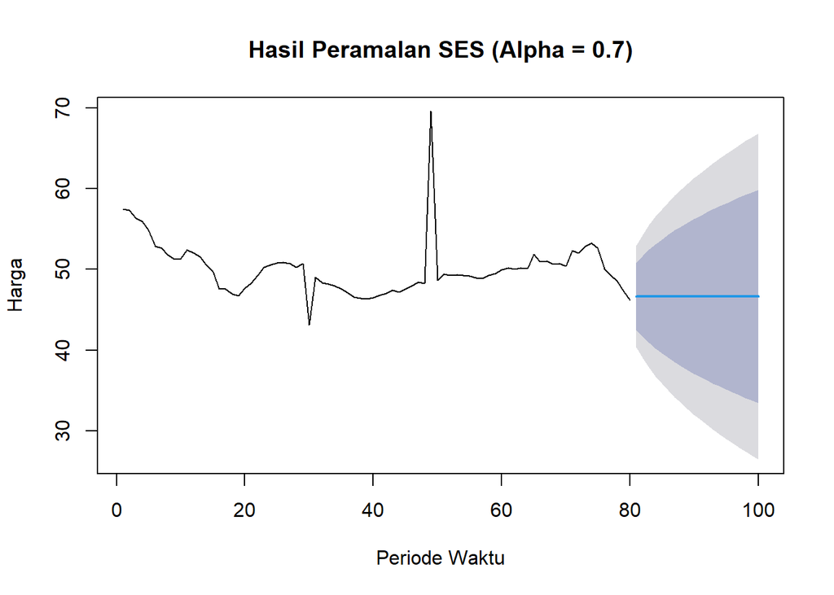

```r
plot(ramalan2, main = "Hasil Peramalan SES (Alpha = 0.7)", ylab = "Harga", xlab = "Periode Waktu")
```

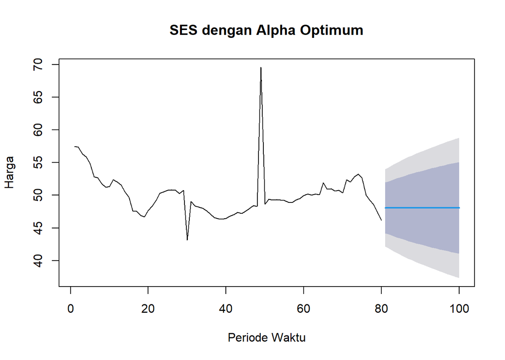

```r
# 1. SES Optimum (fungsi ses)
ses.opt <- ses(train_ma.ts, h = length(test_ma.ts), alpha = NULL)
plot(ses.opt, main = "SES dengan Alpha Optimum", ylab = "Harga", xlab = "Periode Waktu")
```

```r
ses.opt
```

```
##     Point Forecast    Lo 80    Hi 80    Lo 95    Hi 95
##  81       48.07975 44.20899 51.95052 42.15993 53.99958
##  82       48.07975 43.98278 52.17672 41.81398 54.34553
##  83       48.07975 43.76843 52.39107 41.48615 54.67335
##  84       48.07975 43.56424 52.59526 41.17387 54.98563
##  85       48.07975 43.36889 52.79061 40.87512 55.28439
##  86       48.07975 43.18133 52.97817 40.58826 55.57124
##  87       48.07975 43.00069 53.15881 40.31200 55.84751
##  88       48.07975 42.82626 53.33325 40.04523 56.11428
##  89       48.07975 42.65743 53.50207 39.78703 56.37247
##  90       48.07975 42.49371 53.66579 39.53664 56.62287
##  91       48.07975 42.33465 53.82486 39.29337 56.86613
##  92       48.07975 42.17987 53.97963 39.05667 57.10284
##  93       48.07975 42.02906 54.13045 38.82601 57.33349
##  94       48.07975 41.88191 54.27759 38.60097 57.55853
##  95       48.07975 41.73818 54.42133 38.38115 57.77835
##  96       48.07975 41.59763 54.56187 38.16620 57.99330
##  97       48.07975 41.46007 54.69944 37.95581 58.20369
##  98       48.07975 41.32530 54.83420 37.74971 58.40979
##  99       48.07975 41.19318 54.96633 37.54764 58.61186
## 100       48.07975 41.06354 55.09597 37.34938 58.81013
```

```r
# 2. Alpha Optimum HoltWinters
HWopt <- HoltWinters(train_ma.ts, gamma = FALSE, beta = FALSE, alpha = NULL)
HWopt
```

```
## Holt-Winters exponential smoothing without trend and without seasonal component.
##
## Call:
## HoltWinters(x = train_ma.ts, alpha = NULL, beta = FALSE, gamma = FALSE)
##
## Smoothing parameters:
##  alpha: 0.3597597
##  beta : FALSE
##  gamma: FALSE
##
## Coefficients:
##       [,1]
## a 47.99707
```

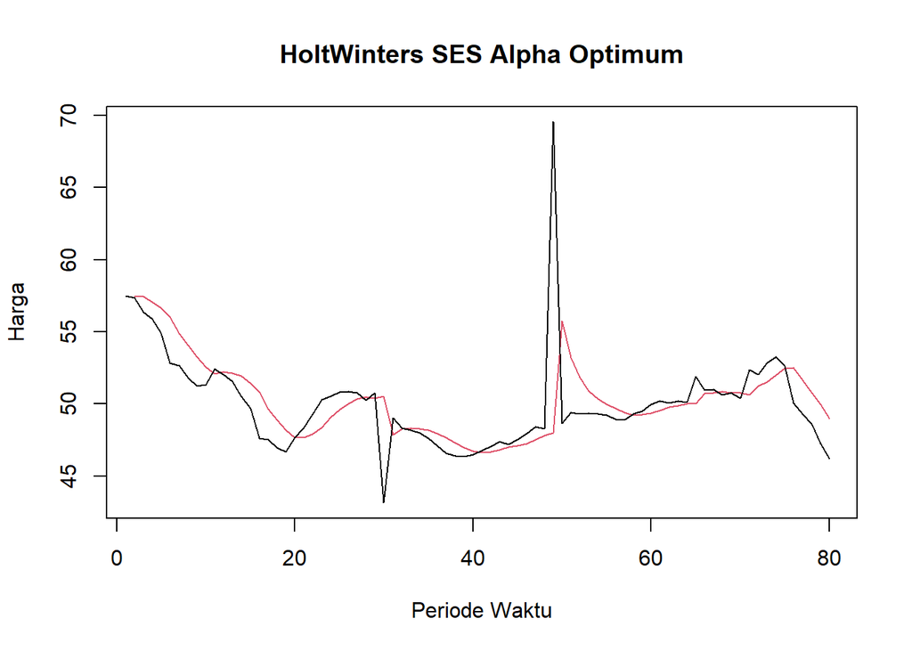

```r
plot(HWopt, main = "HoltWinters SES Alpha Optimum", ylab = "Harga", xlab = "Periode Waktu")
```

```r
# 3. Ramalan 20 periode ke depan (Data Uji)
ramalanopt <- forecast(HWopt, h = length(test_ma.ts))
ramalanopt
```

```
##     Point Forecast    Lo 80    Hi 80    Lo 95    Hi 95
##  81       47.99707 44.14458 51.84956 42.10519 53.88894
##  82       47.99707 43.90285 52.09128 41.73551 54.25863
##  83       47.99707 43.67463 52.31951 41.38646 54.60767
##  84       47.99707 43.45786 52.53628 41.05495 54.93919
##  85       47.99707 43.25098 52.74315 40.73856 55.25558
##  86       47.99707 43.05275 52.94138 40.43539 55.55874
##  87       47.99707 42.86217 53.13196 40.14392 55.85021
##  88       47.99707 42.67841 53.31572 39.86289 56.13124
##  89       47.99707 42.50080 53.49334 39.59125 56.40289
##  90       47.99707 42.32874 53.66539 39.32811 56.66602
##  91       47.99707 42.16176 53.83237 39.07274 56.92140
##  92       47.99707 41.99942 53.99471 38.82446 57.16967
##  93       47.99707 41.84137 54.15277 38.58274 57.41140
##  94       47.99707 41.68727 54.30687 38.34706 57.64707
##  95       47.99707 41.53685 54.45729 38.11701 57.87712
##  96       47.99707 41.38985 54.60429 37.89219 58.10194
##  97       47.99707 41.24605 54.74809 37.67227 58.32186
##  98       47.99707 41.10525 54.88889 37.45694 58.53720
##  99       47.99707 40.96726 55.02687 37.24591 58.74822
## 100       47.99707 40.83194 55.16219 37.03895 58.95518
```

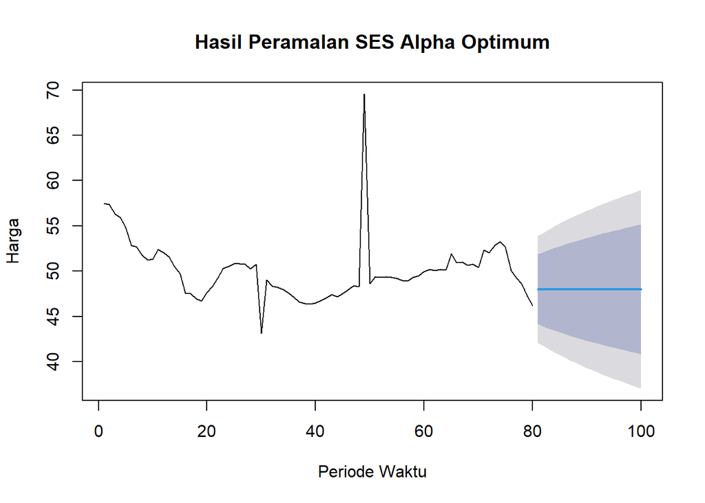

```r
plot(ramalanopt, main = "Hasil Peramalan SES Alpha Optimum", ylab = "Harga", xlab = "Periode Waktu")
```

```r
train.ts <- ts(data_100$Harga[1:80])
train.ts <- ts(data_100[1:80, 1])
# SES dengan alpha = 0.2
SSE1<-ses1$SSE
MSE1<-ses1$SSE/length(train.ts)
RMSE1<-sqrt(MSE1)

akurasi1 <- matrix(c(SSE1,MSE1,RMSE1))
row.names(akurasi1)<- c("SSE", "MSE", "RMSE")
colnames(akurasi1) <- c("Akurasi lamda=0.2")
akurasi1
```

```
##      Akurasi lamda=0.2
## SSE         754.737420
## MSE           9.434218
## RMSE          3.071517
```

```r
# SES dengan alpha = 0.7
SSE2<-ses2$SSE
MSE2<-ses2$SSE/length(train.ts)
RMSE2<-sqrt(MSE2)

akurasi2 <- matrix(c(SSE2,MSE2,RMSE2))
row.names(akurasi2)<- c("SSE", "MSE", "RMSE")
colnames(akurasi2) <- c("Akurasi lamda=0.7")
akurasi2
```

```
##      Akurasi lamda=0.7
## SSE         805.543429
## MSE          10.069293
## RMSE          3.173215
```

```r
# 1. Jumlah observasi data uji
n_test <- length(test_ma.ts)

# 2. Menghitung Error (Ramalan - Aktual)
e1   <- as.numeric(ramalan1$mean)[1:n_test] - as.numeric(test_ma.ts)
e2   <- as.numeric(ramalan2$mean)[1:n_test] - as.numeric(test_ma.ts)
eopt <- as.numeric(ramalanopt$mean)[1:n_test] - as.numeric(test_ma.ts)

# 3. Menghitung Ukuran Kebaikan Model untuk Alpha = 0.2
SSEtesting1  <- sum(e1^2, na.rm = TRUE)
MSEtesting1  <- mean(e1^2, na.rm = TRUE)
RMSEtesting1 <- sqrt(MSEtesting1)
MAPEtesting1 <- mean(abs(e1 / as.numeric(test_ma.ts)) * 100, na.rm = TRUE)

# 4. Menghitung Ukuran Kebaikan Model untuk Alpha = 0.7
SSEtesting2  <- sum(e2^2, na.rm = TRUE)
MSEtesting2  <- mean(e2^2, na.rm = TRUE)
RMSEtesting2 <- sqrt(MSEtesting2)
MAPEtesting2 <- mean(abs(e2 / as.numeric(test_ma.ts)) * 100, na.rm = TRUE)

# 5. Menghitung Ukuran Kebaikan Model untuk Alpha Optimum
SSEtestingopt  <- sum(eopt^2, na.rm = TRUE)
MSEtestingopt  <- mean(eopt^2, na.rm = TRUE)
RMSEtestingopt <- sqrt(MSEtestingopt)
MAPEtestingopt <- mean(abs(eopt / as.numeric(test_ma.ts)) * 100, na.rm = TRUE)

# 6. Menggabungkan Hasil ke dalam Satu Matriks Ringkas
akurasitesting_ses <- matrix(
  c(SSEtesting1, MSEtesting1, RMSEtesting1, MAPEtesting1,
    SSEtesting2, MSEtesting2, RMSEtesting2, MAPEtesting2,
    SSEtestingopt, MSEtestingopt, RMSEtestingopt, MAPEtestingopt),
  nrow = 4,
  byrow = FALSE,
  dimnames = list(c("SSE", "MSE", "RMSE", "MAPE (%)"),
                  c("Alpha = 0.2", "Alpha = 0.7", "Alpha Optimum"))
)

akurasitesting_ses
```

```
##          Alpha = 0.2 Alpha = 0.7 Alpha Optimum
## SSE      1363.535318  707.548163   1019.261903
## MSE        68.176766   35.377408     50.963095
## RMSE        8.256922    5.947891      7.138844
## MAPE (%)   19.196331   13.602932     16.375088
```

Berdasarkan nilai SSE, MSE, RMSE, dan MAPE pada data uji, nilai parameter Alpha = 0.7 (atau $\lambda = 0,7$) menghasilkan akurasi yang paling baik dibandingkan parameter $\alpha = 0,2$ maupun Alpha Optimum.

### DES

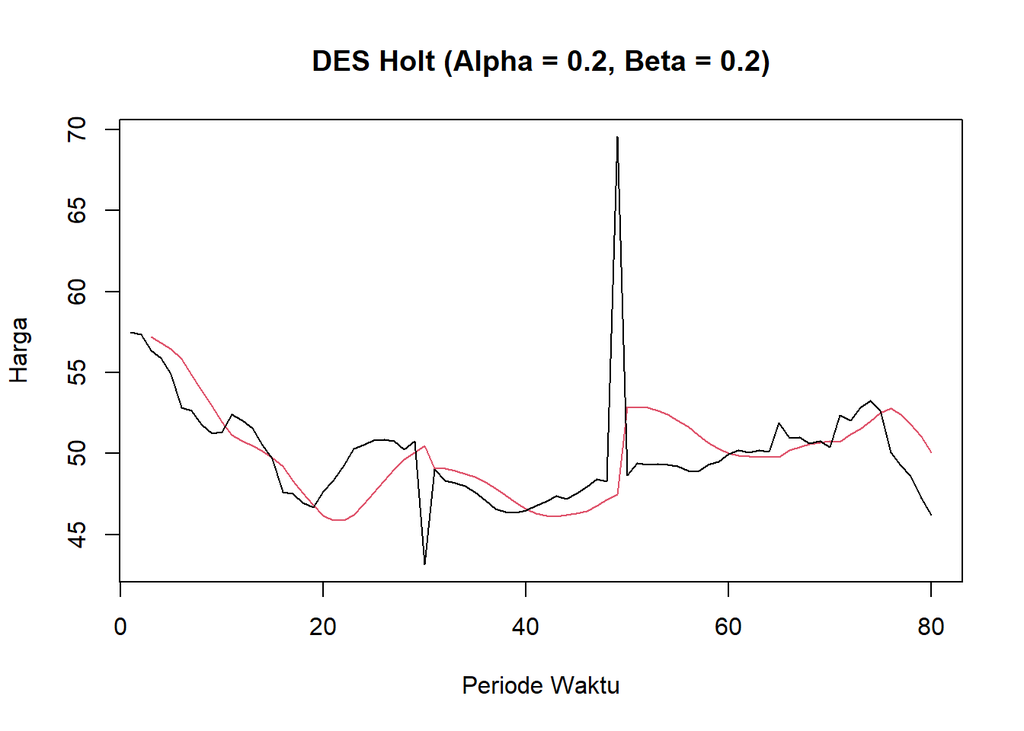

```r
# 1. DES dengan Alpha = 0.2 dan Beta = 0.2
des.1 <- HoltWinters(train_ma.ts, gamma = FALSE, alpha = 0.2, beta = 0.2)
plot(des.1, main = "DES Holt (Alpha = 0.2, Beta = 0.2)", ylab = "Harga", xlab = "Periode Waktu")
```

```r
# Ramalan 20 periode ke depan
ramalandes1 <- forecast(des.1, h = length(test_ma.ts))
ramalandes1
```

```
##     Point Forecast    Lo 80    Hi 80    Lo 95    Hi 95
##  81       48.87694 44.69666 53.05721 42.48376 55.27012
##  82       48.47228 44.17330 52.77127 41.89756 55.04701
##  83       48.06763 43.61215 52.52311 41.25357 54.88169
##  84       47.66298 43.01102 52.31493 40.54843 54.77753
##  85       47.25832 42.36901 52.14764 39.78076 54.73588
##  86       46.85367 41.68633 52.02100 38.95091 54.75643
##  87       46.44901 40.96408 51.93395 38.06054 54.83749
##  88       46.04436 40.20393 51.88479 37.11219 54.97653
##  89       45.63971 39.40787 51.87154 36.10893 55.17048
##  90       45.23505 38.57804 51.89207 35.05402 55.41608
##  91       44.83040 37.71656 51.94424 33.95071 55.71008
##  92       44.42575 36.82546 52.02603 32.80210 56.04939
##  93       44.02109 35.90662 52.13557 31.61107 56.43111
##  94       43.61644 34.96175 52.27112 30.38024 56.85264
##  95       43.21178 33.99240 52.43116 29.11196 57.31161
##  96       42.80713 32.99995 52.61431 27.80834 57.80592
##  97       42.40248 31.98562 52.81934 26.47126 58.33369
##  98       41.99782 30.95050 53.04515 25.10240 58.89325
##  99       41.59317 29.89556 53.29077 23.70322 59.48311
## 100       41.18851 28.82168 53.55535 22.27507 60.10196
```

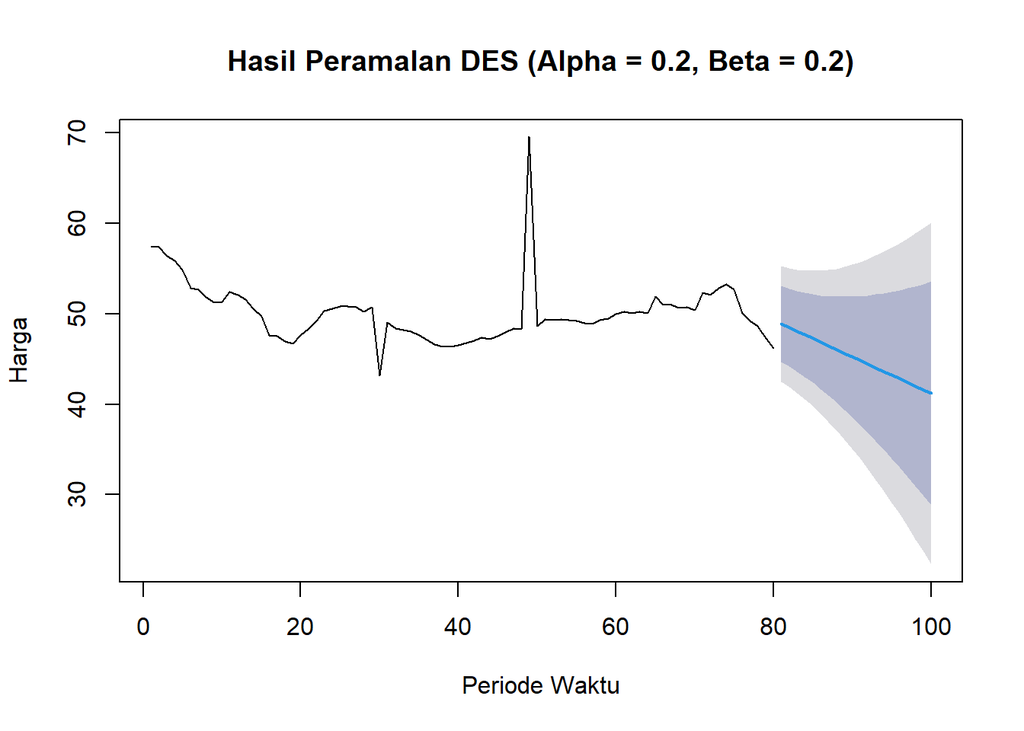

```r
plot(ramalandes1, main = "Hasil Peramalan DES (Alpha = 0.2, Beta = 0.2)", ylab = "Harga", xlab = "Periode Waktu")
```

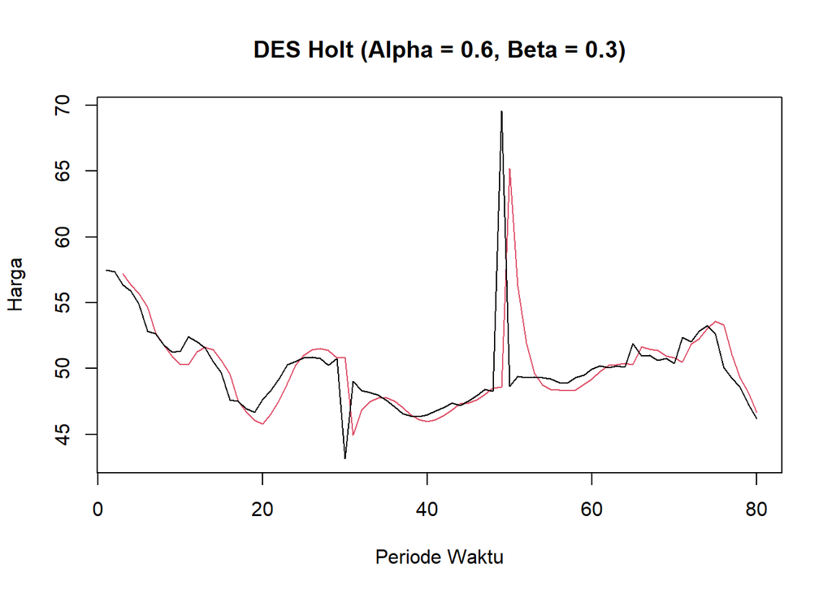

```r
# 2. DES dengan Alpha = 0.6 dan Beta = 0.3
des.2 <- HoltWinters(train_ma.ts, gamma = FALSE, alpha = 0.6, beta = 0.3)
plot(des.2, main = "DES Holt (Alpha = 0.6, Beta = 0.3)", ylab = "Harga", xlab = "Periode Waktu")
```

```r
# Ramalan 20 periode ke depan
ramalandes2 <- forecast(des.2, h = length(test_ma.ts))
ramalandes2
```

```
##     Point Forecast      Lo 80    Hi 80       Lo 95     Hi 95
##  81       45.37981  40.985165 49.77445  38.6587823  52.10083
##  82       44.36980  38.796401 49.94321  35.8460190  52.89359
##  83       43.35980  36.369697 50.34991  32.6693583  54.05025
##  84       42.34980  33.749766 50.94983  29.1971825  55.50242
##  85       41.33980  30.966209 51.71339  25.4747626  57.20483
##  86       40.32980  28.038932 52.62066  21.5325423  59.12705
##  87       39.31979  24.981942 53.65764  17.3919419  61.24764
##  88       38.30979  21.805585 54.81400  13.0687864  63.55079
##  89       37.29979  18.517848 56.08173   8.5752901  66.02429
##  90       36.28979  15.125126 57.45445   3.9212315  68.65834
##  91       35.27978  11.632691 58.92688  -0.8853241  71.44489
##  92       34.26978   8.044999 60.49456  -5.8375628  74.37712
##  93       33.25978   4.365887 62.15367 -10.9296154  77.44917
##  94       32.24978   0.598714 63.90084 -16.1563463  80.65590
##  95       31.23977  -3.253544 65.73309 -21.5132039  83.99275
##  96       30.22977  -7.188222 67.64777 -26.9961107  87.45565
##  97       29.21977 -11.202908 69.64245 -32.6013812  91.04092
##  98       28.20977 -15.295410 71.71494 -38.3256594  94.74519
##  99       27.19976 -19.463715 73.86324 -44.1658693  98.56540
## 100       26.18976 -23.705970 76.08550 -50.1191759 102.49870
```

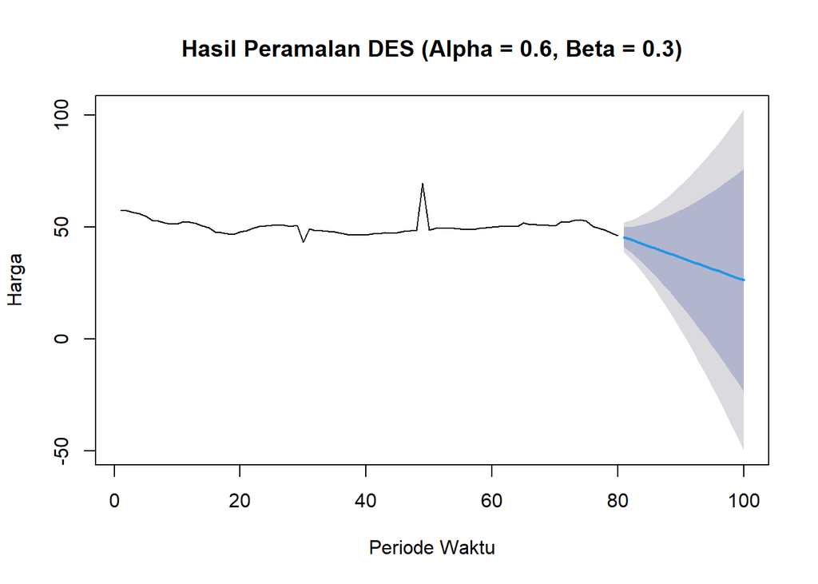

```r
plot(ramalandes2, main = "Hasil Peramalan DES (Alpha = 0.6, Beta = 0.3)", ylab = "Harga", xlab = "Periode Waktu")
```

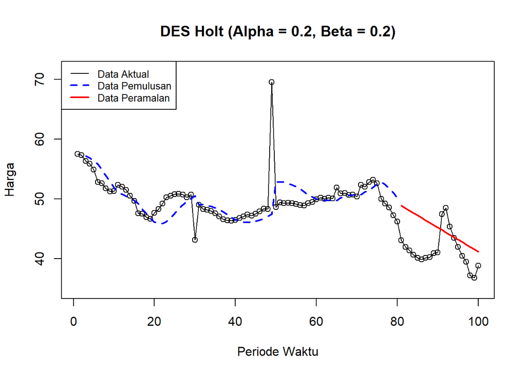

```r
# 1. Plot seluruh data aktual (100 data)
plot(harga.ts,
     col = "black",
     main = "DES Holt (Alpha = 0.2, Beta = 0.2)",
     ylab = "Harga",
     xlab = "Periode Waktu",
     ylim = c(min(harga.ts, na.rm = TRUE) - 2, max(harga.ts, na.rm = TRUE) + 2))

points(harga.ts)

# 2. Garis Pemulusan (fitted values pada data latih)
lines(des.1$fitted[, 1], col = "blue", lty = 2, lwd = 2)

# 3. Garis Peramalan (20 data uji)
lines(ramalandes1$mean, col = "red", lwd = 2)

# 4. Legend
legend("topleft",
       legend = c("Data Aktual", "Data Pemulusan", "Data Peramalan"),
       lty = c(1, 2, 1),
       col = c("black", "blue", "red"),
       lwd = c(1, 2, 2),
       cex = 0.8)
```

```r
# 1. DES Holt Parameter Optimum (alpha & beta NULL otomatis dicari)
des.opt <- HoltWinters(train_ma.ts, gamma = FALSE)
des.opt
```

```
## Holt-Winters exponential smoothing with trend and without seasonal component.
##
## Call:
## HoltWinters(x = train_ma.ts, gamma = FALSE)
##
## Smoothing parameters:
##  alpha: 0.3499893
##  beta : 0
##  gamma: FALSE
##
## Coefficients:
##       [,1]
## a 47.78071
## b -0.15000
```

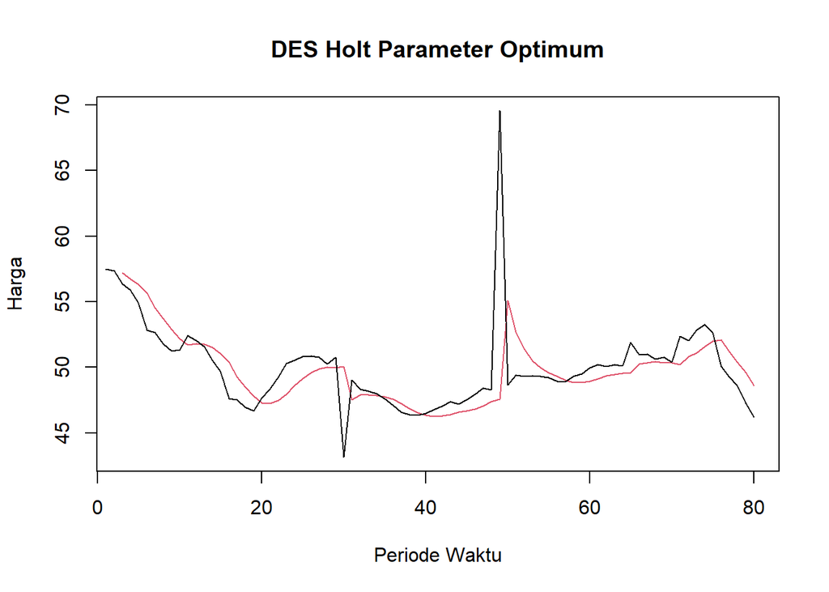

```r
plot(des.opt, main = "DES Holt Parameter Optimum", ylab = "Harga", xlab = "Periode Waktu")
```

```r
# 2. Ramalan 20 periode ke depan (Data Uji)
ramalandesopt <- forecast(des.opt, h = length(test_ma.ts))
ramalandesopt
```

```
##     Point Forecast    Lo 80    Hi 80    Lo 95    Hi 95
##  81       47.63071 43.75058 51.51084 41.69656 53.56486
##  82       47.48071 43.36980 51.59162 41.19361 53.76781
##  83       47.33071 43.00130 51.66012 40.70945 53.95197
##  84       47.18071 42.64331 51.71811 40.24136 54.12006
##  85       47.03071 42.29445 51.76697 39.78723 54.27419
##  86       46.88071 41.95361 51.80781 39.34536 54.41606
##  87       46.73071 41.61989 51.84153 38.91438 54.54704
##  88       46.58071 41.29255 51.86887 38.49316 54.66826
##  89       46.43071 40.97096 51.89046 38.08075 54.78067
##  90       46.28071 40.65461 51.90681 37.67633 54.88509
##  91       46.13071 40.34303 51.91839 37.27922 54.98220
##  92       45.98071 40.03585 51.92557 36.88883 55.07259
##  93       45.83071 39.73271 51.92871 36.50463 55.15679
##  94       45.68071 39.43333 51.92809 36.12617 55.23525
##  95       45.53071 39.13744 51.92398 35.75305 55.30837
##  96       45.38071 38.84480 51.91662 35.38490 55.37652
##  97       45.23071 38.55521 51.90621 35.02142 55.44000
##  98       45.08071 38.26848 51.89294 34.66231 55.49911
##  99       44.93071 37.98444 51.87698 34.30731 55.55411
## 100       44.78071 37.70294 51.85848 33.95620 55.60522
```

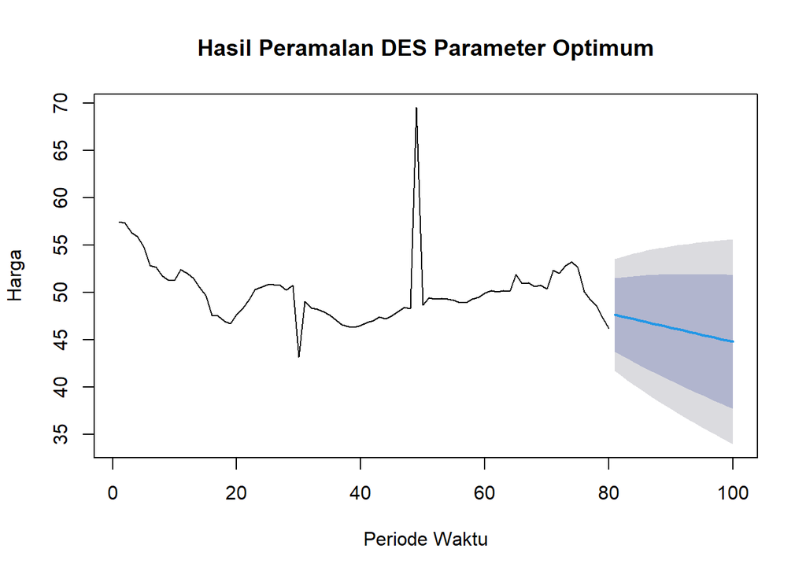

```r
plot(ramalandesopt, main = "Hasil Peramalan DES Parameter Optimum", ylab = "Harga", xlab = "Periode Waktu")
```

```r
# 1. Definisikan dulu variabel SSE, MSE, RMSE, dan MAPE
ssedes.train1  <- des.1$SSE
msedes.train1  <- ssedes.train1 / length(train_ma.ts)
rmsedes.train1 <- sqrt(msedes.train1)
mapedes.train1 <- mean(abs(residuals(des.1) / train_ma.ts) * 100, na.rm = TRUE)

# 2. Lakukan hal yang sama untuk des.2 dan des.opt
ssedes.train2  <- des.2$SSE
msedes.train2  <- ssedes.train2 / length(train_ma.ts)
rmsedes.train2 <- sqrt(msedes.train2)
mapedes.train2 <- mean(abs(residuals(des.2) / train_ma.ts) * 100, na.rm = TRUE)

ssedes.trainopt  <- des.opt$SSE
msedes.trainopt  <- ssedes.trainopt / length(train_ma.ts)
rmsedes.trainopt <- sqrt(msedes.trainopt)
mapedes.trainopt <- mean(abs(residuals(des.opt) / train_ma.ts) * 100, na.rm = TRUE)

# 3. Baru panggil ke dalam fungsi matrix()
akurasitrain_des <- matrix(
  c(ssedes.train1, msedes.train1, rmsedes.train1, mapedes.train1,
    ssedes.train2, msedes.train2, rmsedes.train2, mapedes.train2,
    ssedes.trainopt, msedes.trainopt, rmsedes.trainopt, mapedes.trainopt),
  nrow = 4,
  byrow = FALSE,
  dimnames = list(c("SSE", "MSE", "RMSE", "MAPE (%)"),
                  c("Alpha=0.2 & Beta=0.2", "Alpha=0.6 & Beta=0.3", "DES Optimum"))
)

akurasitrain_des
```

```
##          Alpha=0.2 & Beta=0.2 Alpha=0.6 & Beta=0.3 DES Optimum
## SSE                819.792484           905.744788  706.323935
## MSE                 10.247406            11.321810    8.829049
## RMSE                 3.201157             3.364790    2.971372
## MAPE (%)             3.609709             2.727085    2.902100
```

Model DES Optimum memberikan akurasi terbaik pada data latih dengan nilai SSE 706,32, MSE 8,83, RMSE 2,97, dan MAPE 2,90%. Nilai MAPE yang di bawah 10% ini menunjukkan bahwa kinerjanya tergolong sangat baik.

```r
# 1. Menghitung Selisih Error (Ramalan - Data Uji Aktual)
selisihdes1   <- as.numeric(ramalandes1$mean) - as.numeric(test_ma.ts)
selisihdes2   <- as.numeric(ramalandes2$mean) - as.numeric(test_ma.ts)
selisihdesopt <- as.numeric(ramalandesopt$mean) - as.numeric(test_ma.ts)

# 2. Akurasi DES Skenario 1 (Alpha = 0.2, Beta = 0.2)
SSEtestingdes1  <- sum(selisihdes1^2, na.rm = TRUE)
MSEtestingdes1  <- mean(selisihdes1^2, na.rm = TRUE)
RMSEtestingdes1 <- sqrt(MSEtestingdes1)
MAPEtestingdes1 <- mean(abs(selisihdes1 / as.numeric(test_ma.ts)) * 100, na.rm = TRUE)

# 3. Akurasi DES Skenario 2 (Alpha = 0.6, Beta = 0.3)
SSEtestingdes2  <- sum(selisihdes2^2, na.rm = TRUE)
MSEtestingdes2  <- mean(selisihdes2^2, na.rm = TRUE)
RMSEtestingdes2 <- sqrt(MSEtestingdes2)
MAPEtestingdes2 <- mean(abs(selisihdes2 / as.numeric(test_ma.ts)) * 100, na.rm = TRUE)

# 4. Akurasi DES Skenario Optimum
SSEtestingdesopt  <- sum(selisihdesopt^2, na.rm = TRUE)
MSEtestingdesopt  <- mean(selisihdesopt^2, na.rm = TRUE)
RMSEtestingdesopt <- sqrt(MSEtestingdesopt)
MAPEtestingdesopt <- mean(abs(selisihdesopt / as.numeric(test_ma.ts)) * 100, na.rm = TRUE)

# 5. Penggabungan ke Matriks Ringkasan Akurasi Data Uji
akurasitestingdes <- matrix(
  c(SSEtestingdes1, MSEtestingdes1, RMSEtestingdes1, MAPEtestingdes1,
    SSEtestingdes2, MSEtestingdes2, RMSEtestingdes2, MAPEtestingdes2,
    SSEtestingdesopt, MSEtestingdesopt, RMSEtestingdesopt, MAPEtestingdesopt),
  nrow = 4,
  byrow = FALSE,
  dimnames = list(c("SSE", "MSE", "RMSE", "MAPE (%)"),
                  c("DES Ske 1", "DES Ske 2", "DES Optimum"))
)

akurasitestingdes
```

```
##           DES Ske 1   DES Ske 2 DES Optimum
## SSE      470.792916 1344.814298  608.848009
## MSE       23.539646   67.240715   30.442400
## RMSE       4.851767    8.200044    5.517463
## MAPE (%)  10.684140   15.941398   12.702034
```

Untuk peramalan data uji, DES Skenario 1 (α=0,2 dan β=0,2) menjadi model paling unggul dengan nilai SSE 470,79, MSE 23,54, RMSE 4,85, dan MAPE 10,68%. Dengan tingkat MAPE di rentang 10%–20%, kemampuan peramalannya tergolong baik.

## Kesimpulan

Metode Double Exponential Smoothing (DES) Skenario 1 (α=0,2 dan β=0,2) terpilih sebagai model terbaik untuk meramalkan harga cabai merah. Model ini menghasilkan tingkat kesalahan terendah pada data uji dengan RMSE 4,85 dan MAPE 10,68% (kategori peramalan Baik).